# Chapter 8

jim108@gmx.net

5/26/2020

## 8E1.

For each of the causal relationships below, name a hypothetical third variable that would lead to an interaction effect.

1. Bread dough rises because of yeast.
2. Education leads to higher income.
3. Gasoline makes a car go.

Sol.:

1. Bread dough rises because of yeast **and water**.
2. Education and **a good neighborhood** leads to higher income.
3. Gasoline **and traction** makes a car go.

## 8E2.

Which of the following explanations invokes an interaction?

1. Caramelizing onions requires cooking over low heat (H) and making sure the onions do not dry out (W).
2. A car will go faster when it has more cylinders (C) or when it has a better fuel injector (I).
3. Most people acquire their political beliefs from their parents (P), unless they get them instead from their friends (F).
4. Intelligent animal species tend to be either highly social(S) or have manipulative appendages (hands, tentacles, etc.) (M).

Sol.:

1. Interaction between heat and water.
2. No interaction because a cylinder extra does make the fuel injector better or worse.
3. Interaction because parents can influence the choise of friends and viced versa.
4. Interaction because manipulative appendages like hands for example can influence social interactions.

## 8E3.

Want: Linar model of 8E2.

Sol.: Only the interaction equation is stated.

1. $\mu_i = \alpha + \beta_H H_i + \beta_{HW} H_i W_i + \beta_W W_i$.
2. $\mu_i = \alpha + \beta_C C_i + \beta_F F_i$.
3. $\mu_i = \alpha + \beta_P P_i + \beta_{PF} P_i F_i + \beta_F F_i$.
4. $\mu_i = \alpha + \beta_S S_i + \beta_{SM} S_i M_i + \beta_M M_i$.

## 8M1.

Given: Tulip data + temperature (T) $\in$ {cold(0), hot(1)}. Normal plant growth at cold temperatures. No plant growth at hot temperature.

Want: Interaction model.

Sol.:

CIT[i] = T + 1

$\mu_i = \alpha_{CIT[i]} + \beta_{W CIT[i]} W_i + \beta_{WS CIT[i]} S_i W_i + \beta_{S CIT[i]} S_i$.

## 8M2.

Given: 8M1 + zero plant growth if the temperature is hot.

Want: regression equation.

## 8M3.

Given: Raven population size (R), wolf population (W), food supply of wolfs (F), raven co-feed at wolfs food.

Want: Hypothetical data set. Linear? Why?

Sol.:

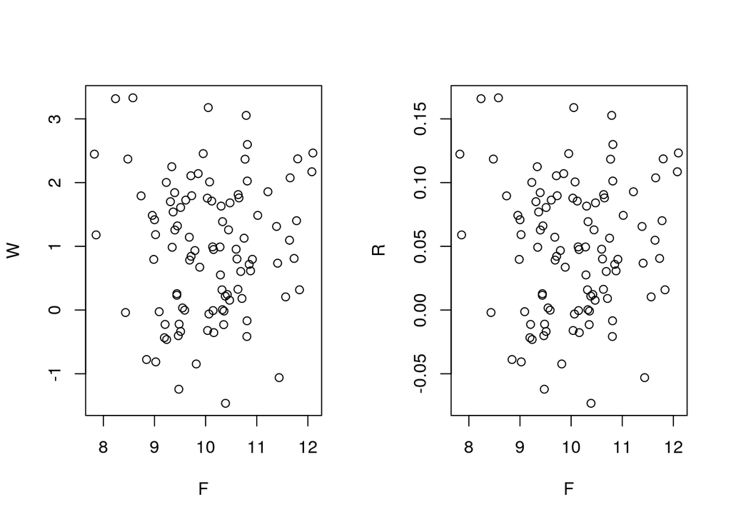

```r
rho <- 0.05
F <- rnorm(100,10)
W <- rnorm(F,1)
R <- rho * W

par(mfrow=c(1,2))
plot(W ~ F)
plot(R ~ F)
```

## 8H1.

Given: Tulip data.

Want: Include ´bed´ as a main effect.

Sol.:

```r
data(tulips)
d <- tulips
```

```r
d$blooms_std <- d$blooms / max(d$blooms)
d$water_cent <- d$water - mean(d$water)
d$shade_cent <- d$shade - mean(d$shade)
d$cib <- as.numeric(d$bed)

m8H1 <- quap(
    alist(
        blooms_std ~ dnorm( mu , sigma ) ,
        mu <- a[cib] + bw[cib]*water_cent + bs[cib]*shade_cent + bws[cib]*water_cent*shade_cent ,
        a[cib] ~ dnorm( 0.5 , 0.25 ) ,
        bw[cib] ~ dnorm( 0 , 0.25 ) ,
        bs[cib] ~ dnorm( 0 , 0.25 ) ,
        bws[cib] ~ dnorm( 0 , 0.25 ) ,
        sigma ~ dexp( 1 )
    ) , data=d )

precis(m8H1, depth = 2)
```

```
##               mean         sd        5.5%       94.5%
## a[1]    0.27154839 0.02851321  0.22597877  0.31711801
## a[2]    0.39562275 0.02850421  0.35006752  0.44117798
## a[3]    0.40842465 0.02850363  0.36287034  0.45397896
## bw[1]   0.15032127 0.03480364  0.09469833  0.20594421
## bw[2]   0.22948982 0.03481554  0.17384786  0.28513179
## bw[3]   0.23679677 0.03481695  0.18115256  0.29244098
## bs[1]  -0.03872391 0.03479516 -0.09433329  0.01688548
## bs[2]  -0.19640506 0.03480999 -0.25203816 -0.14077197
## bs[3]  -0.10328963 0.03479878 -0.15890480 -0.04767446
## bws[1] -0.13498690 0.04242276 -0.20278666 -0.06718713
## bws[2] -0.11178287 0.04241862 -0.17957601 -0.04398972
## bws[3] -0.17902858 0.04243278 -0.24684435 -0.11121281
## sigma   0.08606655 0.01172380  0.06732965  0.10480344
```

## 8H2.

Given: 8H1.

Want: Compare 8H1 WAIC to a model without bed.

Sol.:

```r
m8.5 <- quap(
    alist(
        blooms_std ~ dnorm( mu , sigma ) ,
        mu <- a + bw*water_cent + bs*shade_cent + bws*water_cent*shade_cent ,
        a ~ dnorm( 0.5 , 0.25 ) ,
        bw ~ dnorm( 0 , 0.25 ) ,
        bs ~ dnorm( 0 , 0.25 ) ,
        bws ~ dnorm( 0 , 0.25 ) ,
        sigma ~ dexp( 1 )
    ) , data=d )

precis(m8.5)
```

```
##             mean         sd        5.5%       94.5%
## a      0.3579827 0.02391881  0.31975581  0.39620958
## bw     0.2067309 0.02923452  0.16000852  0.25345333
## bs    -0.1134607 0.02922750 -0.16017187 -0.06674948
## bws   -0.1431634 0.03567963 -0.20018629 -0.08614042
## sigma  0.1248449 0.01694041  0.09777082  0.15191893
```

```r
compare(m8H1, m8.5 )
```

```
##           WAIC       SE    dWAIC      dSE     pWAIC    weight
## m8.5 -21.65227 10.64189 0.000000       NA  6.819042 0.7805611
## m8H1 -19.11439 12.25236 2.537879 11.94231 16.988183 0.2194389
```

- The model without ´bed´ makes better predictions according to WAIC.
- The std. error of the difference to the best model is higher than the difference to the best model.
- Thus, the comarison is not reliable.

## 8H3.

Given: rugged data.

Want: (a) Measure relative influence of each country with WAIC pointwise penalties and PSIS.By these criteria, is Seychelles influencing the results? Are there other nations that are relatively influential? Explain why?

Sol.:

```r
data(rugged)
d <- rugged
d$log_gdp <- log(d$rgdppc_2000)
dd <- d[ complete.cases(d$rgdppc_2000) , ]
dd$log_gdp_std <- dd$log_gdp / mean(dd$log_gdp)
dd$rugged_std <- dd$rugged / max(dd$rugged)
dd$cid <- ifelse( dd$cont_africa==1 , 1 , 2 )
```

```r
m8.3 <- quap(
    alist(
        log_gdp_std ~ dnorm( mu , sigma ) ,
        mu <- a[cid] + b[cid]*( rugged_std - 0.215 ) ,
        a[cid] ~ dnorm( 1 , 0.1 ) ,
        b[cid] ~ dnorm( 0 , 0.3 ) ,
        sigma ~ dexp( 1 )
    ) , data=dd )
precis( m8.3 , depth=2 )
```

```
##             mean          sd        5.5%       94.5%
## a[1]   0.8865609 0.015675361  0.86150864  0.91161315
## a[2]   1.0505722 0.009936393  1.03469196  1.06645251
## b[1]   0.1324947 0.074202955  0.01390407  0.25108538
## b[2]  -0.1425798 0.054748261 -0.23007809 -0.05508149
## sigma  0.1094918 0.005934979  0.10000652  0.11897701
```

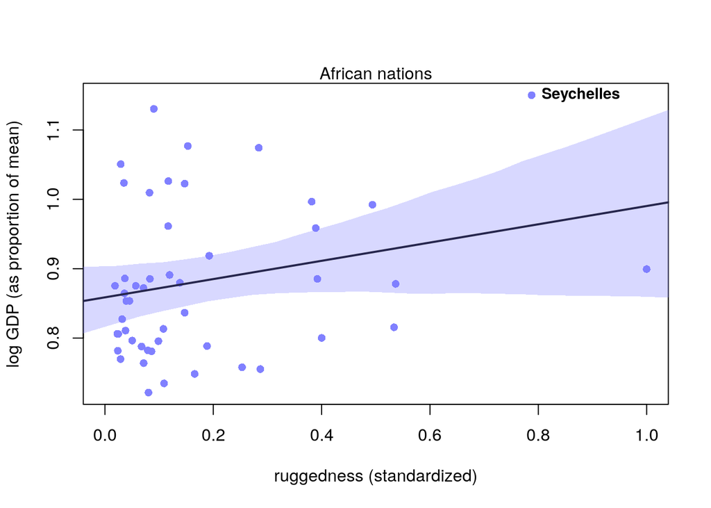

```r
d.A1 <- dd[ dd$cid==1 , ]
plot( d.A1$rugged_std , d.A1$log_gdp_std , pch=16 , col=rangi2 ,
    xlab="ruggedness (standardized)" , ylab="log GDP (as proportion of mean)" ,
    xlim=c(0,1) )
rugged.seq <- seq( from=-0.1 , to=1.1 , length.out=30 )
mu <- link( m8.3 , data=data.frame( cid=1 , rugged_std=rugged.seq ) )
mu_mean <- apply( mu , 2 , mean )
mu_ci <- apply( mu , 2 , PI , prob=0.97 )
lines( rugged.seq , mu_mean , lwd=2 )
shade( mu_ci , rugged.seq , col=col.alpha(rangi2,0.3) )
mtext("African nations")
dsyc <- dd[ dd$isocode=="SYC",]
text(dsyc$log_gdp_std~dsyc$rugged_std, labels=country, data=dsyc, cex=0.9, font=2, pos=4)
```

```r
dd$penalty <- WAIC(m8.3, pointwise = TRUE)$penalty
dd$k <- PSIS( m8.3, pointwise = TRUE)$k
```

```
## Some Pareto k values are high (>0.5). Set pointwise=TRUE to inspect individual points.
```

```r
measures <- dd[which(dd$cid == 1),c("country", "penalty", "k")]
measures <- measures[with(measures, order(-penalty)), ]
head(measures)
```

```
##               country    penalty           k
## 199        Seychelles 0.65078622  0.45618657
## 122           Lesotho 0.30024868  0.58324503
## 82  Equatorial Guinea 0.21761310  0.16369005
## 33           Botswana 0.11083741 -0.02585658
## 179            Rwanda 0.09050144  0.19864012
## 144         Mauritius 0.08829913  0.07086371
```

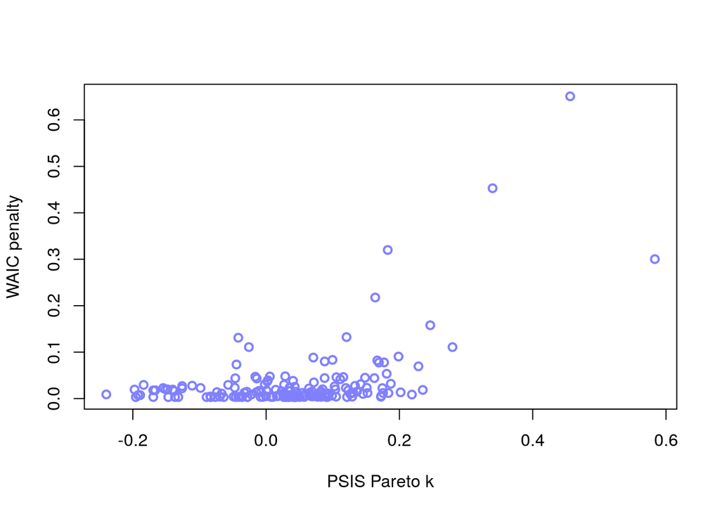

```r
plot( dd$k , dd$penalty , xlab="PSIS Pareto k" ,
    ylab="WAIC penalty" , col=rangi2 , lwd=2 )
```

Want: (b)Modify m8.5 to use a Student-t distribution with ν = 2. Does this change the results in a substantial way?

Sol.:

```r
m8.3t <- quap(
    alist(
        log_gdp_std ~ dstudent( 2, mu , sigma ) ,
        mu <- a[cid] + b[cid]*( rugged_std - 0.215 ) ,
        a[cid] ~ dnorm( 1 , 0.1 ) ,
        b[cid] ~ dnorm( 0 , 0.3 ) ,
        sigma ~ dexp( 1 )
    ) , data=dd )
precis( m8.3t , depth=2 )
```

```
##              mean          sd         5.5%       94.5%
## a[1]   0.86263418 0.016149751  0.836823762  0.88844460
## a[2]   1.04572946 0.010971394  1.028195052  1.06326387
## b[1]   0.11266821 0.075141366 -0.007422209  0.23275862
## b[2]  -0.21367174 0.063532734 -0.315209319 -0.11213416
## sigma  0.08452617 0.006732416  0.073766471  0.09528587
```

```r
dd$penalty <- WAIC(m8.3t, pointwise = TRUE)$penalty
dd$k <- PSIS( m8.3t, pointwise = TRUE)$k
measures <- dd[which(dd$cid == 1),c("country", "penalty", "k")]
measures <- measures[with(measures, order(-penalty)), ]
head(measures)
```

```
##        country    penalty           k
## 199 Seychelles 0.29075266  0.08535757
## 122    Lesotho 0.25458516  0.04299046
## 198  Swaziland 0.13130617 -0.03692693
## 179     Rwanda 0.12994343  0.02850254
## 47  Cape Verde 0.08827995 -0.22426909
## 62     Eritrea 0.07778569  0.06681260
```

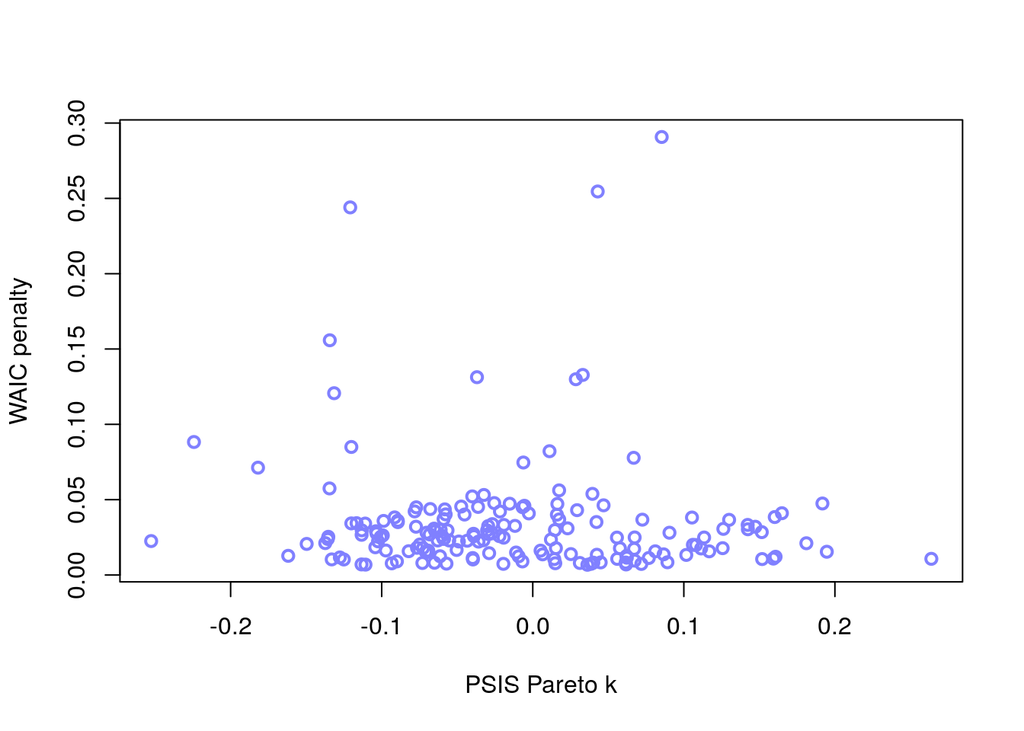

```r
plot( dd$k , dd$penalty , xlab="PSIS Pareto k" ,
    ylab="WAIC penalty" , col=rangi2 , lwd=2 )
```

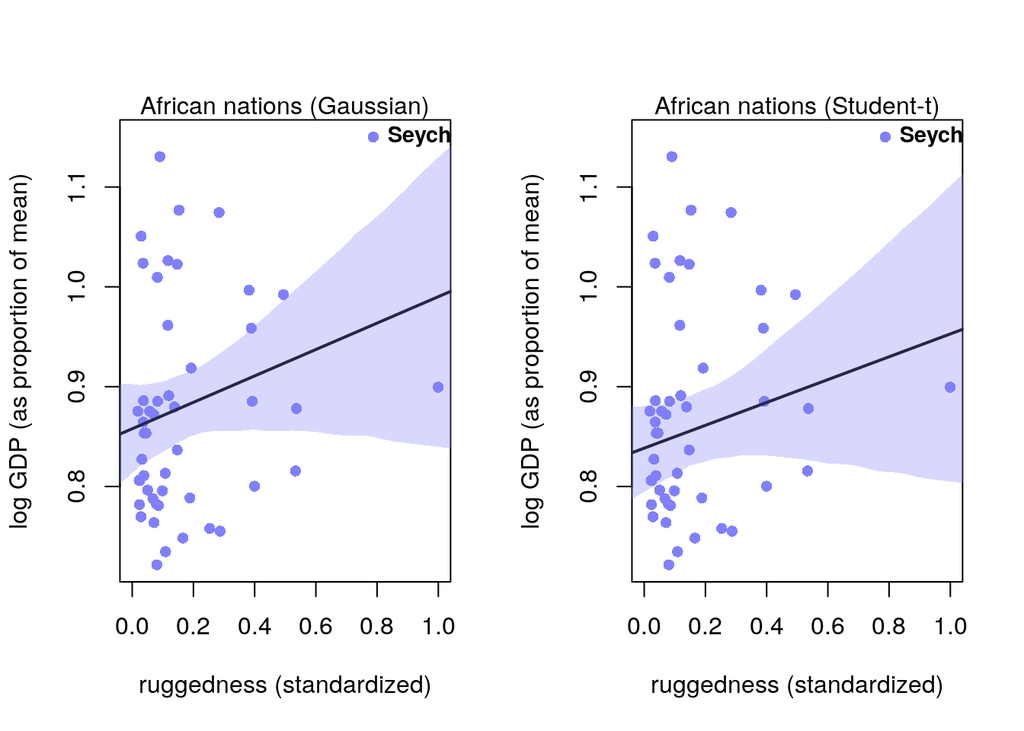

```r
par(mfrow=c(1,2))
d.A1 <- dd[ dd$cid==1 , ]
plot( d.A1$rugged_std , d.A1$log_gdp_std , pch=16 , col=rangi2 ,
    xlab="ruggedness (standardized)" , ylab="log GDP (as proportion of mean)" ,
    xlim=c(0,1) )
rugged.seq <- seq( from=-0.1 , to=1.1 , length.out=30 )
mu <- link( m8.3 , data=data.frame( cid=1 , rugged_std=rugged.seq ) )
mu_mean <- apply( mu , 2 , mean )
mu_ci <- apply( mu , 2 , PI , prob=0.97 )
lines( rugged.seq , mu_mean , lwd=2 )
shade( mu_ci , rugged.seq , col=col.alpha(rangi2,0.3) )
mtext("African nations (Gaussian)")
dsyc <- dd[ dd$isocode=="SYC",]
text(dsyc$log_gdp_std~dsyc$rugged_std, labels=country, data=dsyc, cex=0.9, font=2, pos=4)


d.A1 <- dd[ dd$cid==1 , ]
plot( d.A1$rugged_std , d.A1$log_gdp_std , pch=16 , col=rangi2 ,
    xlab="ruggedness (standardized)" , ylab="log GDP (as proportion of mean)" ,
    xlim=c(0,1) )
rugged.seq <- seq( from=-0.1 , to=1.1 , length.out=30 )
mu <- link( m8.3t , data=data.frame( cid=1 , rugged_std=rugged.seq ) )
mu_mean <- apply( mu , 2 , mean )
mu_ci <- apply( mu , 2 , PI , prob=0.97 )
lines( rugged.seq , mu_mean , lwd=2 )
shade( mu_ci , rugged.seq , col=col.alpha(rangi2,0.3) )
mtext("African nations (Student-t)")
dsyc <- dd[ dd$isocode=="SYC",]
text(dsyc$log_gdp_std~dsyc$rugged_std, labels=country, data=dsyc, cex=0.9, font=2, pos=4)
```

## 8H4.

Given: Nettle data on language diversity in 74 nations.

Want: Verify claims. Consider log(area) as a covariate (not an interaction) for (a) and (b). Interpret results.

Claims:

1. Language diversity, as measured by log(´lang.per.cap´), is positively associated with the average length of the growing season, ´mean.growing.season´.

```r
data("nettle")

d <- nettle

d$lang.per.cap <- d$num.lang / d$k.pop

summary(d)
```

```
##        country      num.lang           area             k.pop
##  Algeria   : 1   Min.   :  1.00   Min.   :  12189   Min.   :   102
##  Angola    : 1   1st Qu.: 17.25   1st Qu.: 167708   1st Qu.:  3829
##  Australia : 1   Median : 40.00   Median : 434796   Median :  9487
##  Bangladesh: 1   Mean   : 89.73   Mean   : 880698   Mean   : 33574
##  Benin     : 1   3rd Qu.: 93.75   3rd Qu.:1080316   3rd Qu.: 24744
##  Bolivia   : 1   Max.   :862.00   Max.   :8511965   Max.   :849638
##  (Other)   :68
##   num.stations    mean.growing.season sd.growing.season  lang.per.cap
##  Min.   :  1.00   Min.   : 0.000      Min.   :0.0000    Min.   :0.0000931
##  1st Qu.: 10.00   1st Qu.: 5.348      1st Qu.:0.9375    1st Qu.:0.0019901
##  Median : 20.50   Median : 7.355      Median :1.6900    Median :0.0041066
##  Mean   : 37.91   Mean   : 7.041      Mean   :1.6992    Mean   :0.0206464
##  3rd Qu.: 44.75   3rd Qu.: 9.283      3rd Qu.:2.1075    3rd Qu.:0.0100059
##  Max.   :272.00   Max.   :12.000      Max.   :5.8700    Max.   :0.6809816
##
```

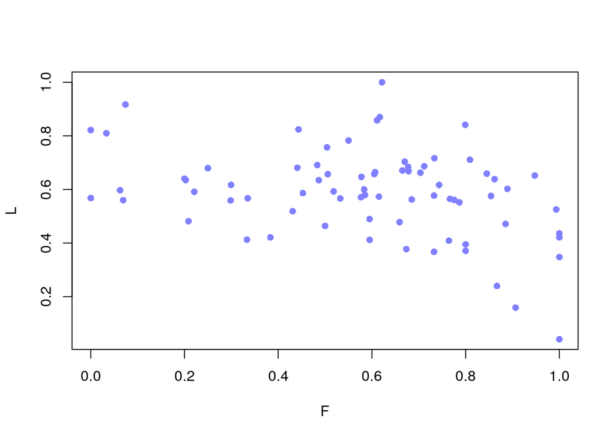

```r
d$F <- d$mean.growing.season / max(d$mean.growing.season)
log_lang <- log(d$lang.per.cap)
d$L <- log_lang / min(log_lang)

plot(d$F, d$L, pch=16 , col=rangi2, xlab="F" , ylab="L" )
```

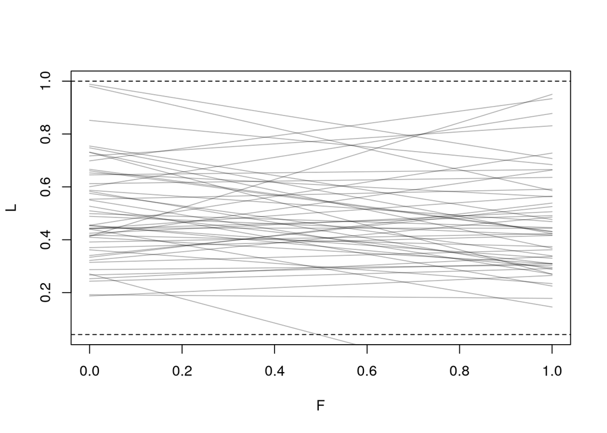

```r
set.seed(1)
m8H4a<- quap(
    alist(
        L ~ dnorm( mu , sigma ) ,
        mu <- a + b*F ,
        a ~ dnorm( 0.5 , 0.2 ) ,
        b ~ dnorm( 0 , 0.2 ) ,
        sigma ~ dexp( 1 )
    ) , data=d )

prior <- extract.prior( m8H4a)

plot( NULL , xlim=c(0,1) , ylim=c(min(d$L),max(d$L)) ,
    xlab="F" , ylab="L" )
abline( h=min(d$L) , lty=2 )
abline( h=max(d$L) , lty=2 )

F_seq <- seq( from=min(d$F) , to=max(d$F) , length.out=30 )
mu <- link( m8H4a, post=prior , data=data.frame(F=F_seq) )
for ( i in 1:50 ) lines( F_seq , mu[i,] , col=col.alpha("black",0.3) )
```

```r
set.seed(24071847)
PSIS_m8H4a <- PSIS(m8H4a,pointwise=TRUE)
```

```
## Some Pareto k values are high (>0.5). Set pointwise=TRUE to inspect individual points.
```

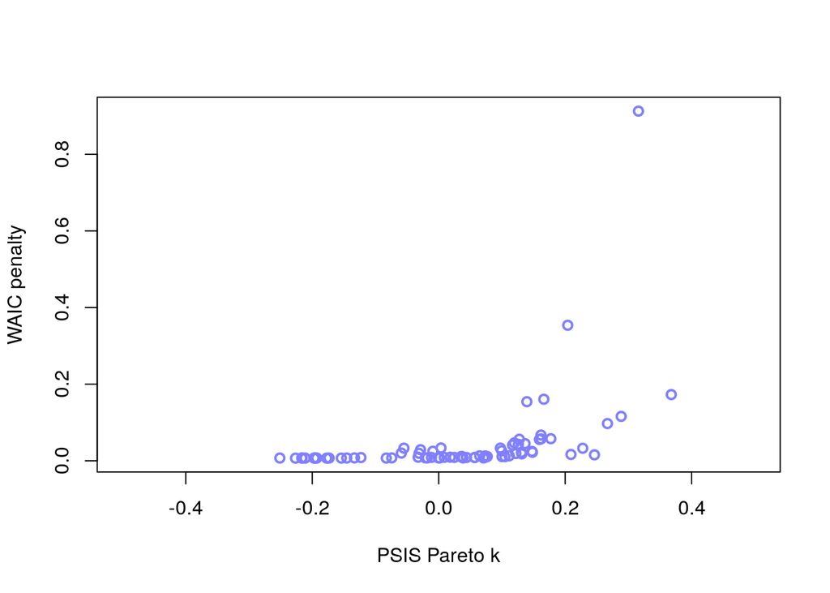

```r
set.seed(24071847)
WAIC_m8H4a <- WAIC(m8H4a,pointwise=TRUE)
plot( PSIS_m8H4a$k , WAIC_m8H4a$penalty , xlab="PSIS Pareto k" ,
    ylab="WAIC penalty" , col=rangi2 , lwd=2, xlim=c(-0.5,0.5) )
```

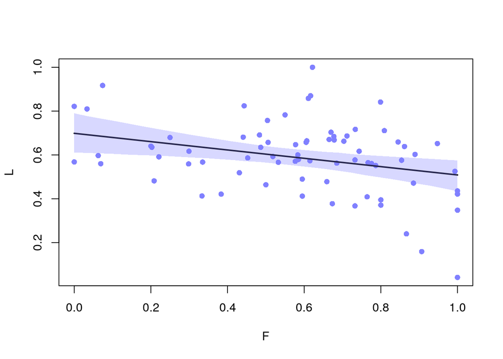

```r
plot(d$F, d$L, pch=16 , col=rangi2, xlab="F" , ylab="L" )
mu <- link( m8H4a, data=data.frame(F=F_seq ) )
mu_mean <- apply( mu , 2 , mean )
mu_ci <- apply( mu , 2 , PI , prob=0.97 )
lines( F_seq , mu_mean , lwd=2 )
shade( mu_ci , F_seq , col=col.alpha(rangi2,0.3) )
```

```r
precis(m8H4a)
```

```
##             mean         sd       5.5%       94.5%
## a      0.6976762 0.04090557  0.6323012  0.76305117
## b     -0.1896891 0.06338465 -0.2909901 -0.08838823
## sigma  0.1519793 0.01251150  0.1319835  0.17197511
```

The evaluation does not support this claim.

2. Language diversity is negatively associated with the standard deviation of length of growing season, ´sd.growing.season´. This hypothesis follows from uncertainty in harvest favoring social insurance through larger social networks and therefore fewer languages.

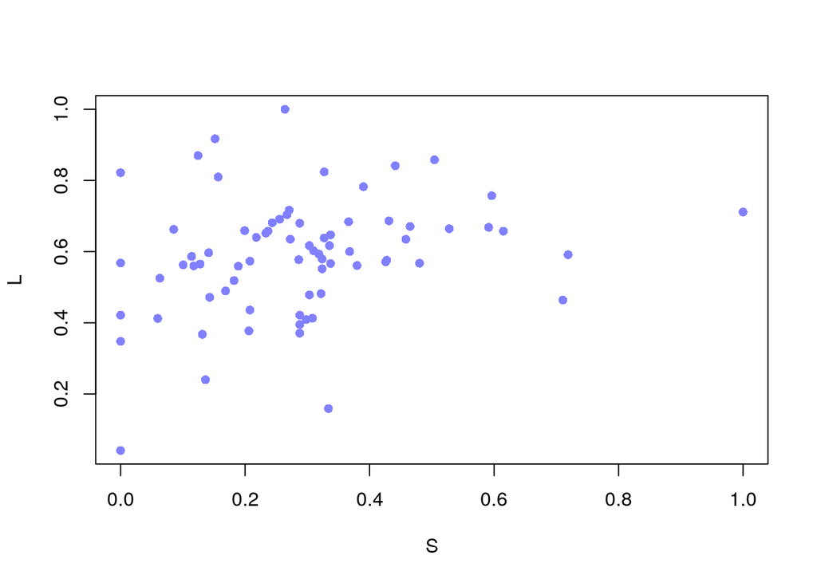

```r
d$S <- d$sd.growing.season / max(d$sd.growing.season)
log_lang <- log(d$lang.per.cap)
d$L <- log_lang / min(log_lang)

plot(d$S, d$L, pch=16 , col=rangi2, xlab="S" , ylab="L" )
```

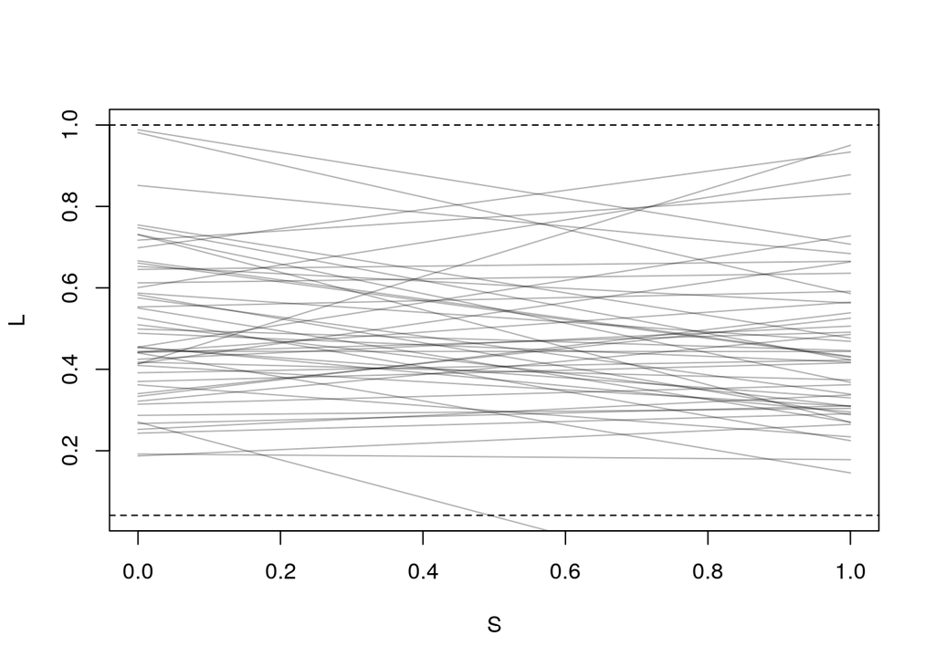

```r
set.seed(1)
m8H4b <- quap(
    alist(
        L ~ dnorm( mu , sigma ) ,
        mu <- a + b*S ,
        a ~ dnorm( 0.5 , 0.2 ) ,
        b ~ dnorm( 0 , 0.2 ) ,
        sigma ~ dexp( 1 )
    ) , data=d )

prior <- extract.prior( m8H4b )

plot( NULL , xlim=c(0,1) , ylim=c(min(d$L),max(d$L)) ,
    xlab="S" , ylab="L" )
abline( h=min(d$L) , lty=2 )
abline( h=max(d$L) , lty=2 )

S_seq <- seq( from=min(d$S) , to=max(d$S) , length.out=30 )
mu <- link( m8H4b , post=prior , data=data.frame(S=S_seq) )
for ( i in 1:50 ) lines( S_seq , mu[i,] , col=col.alpha("black",0.3) )
```

```r
set.seed(24071847)
PSIS_m8H4b <- PSIS(m8H4b,pointwise=TRUE)
```

```
## Some Pareto k values are high (>0.5). Set pointwise=TRUE to inspect individual points.
```

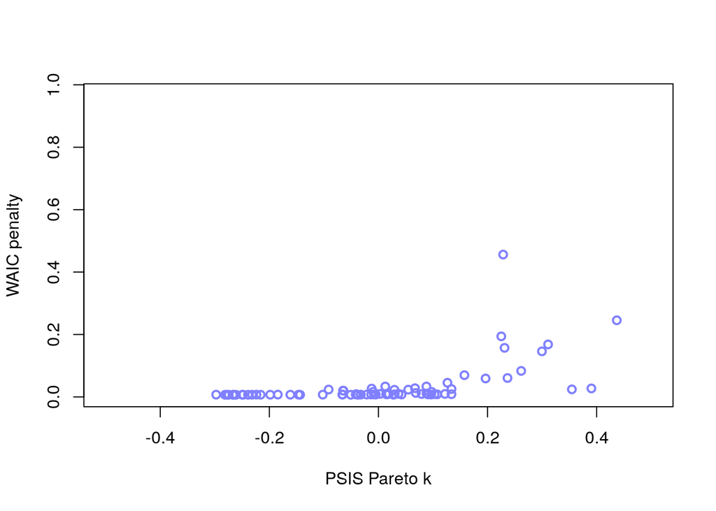

```r
set.seed(24071847)
WAIC_m8H4b <- WAIC(m8H4b,pointwise=TRUE)
plot( PSIS_m8H4b$k , WAIC_m8H4b$penalty , xlab="PSIS Pareto k" ,
    ylab="WAIC penalty" , col=rangi2 , lwd=2, xlim=c(-0.5,0.5) )
```

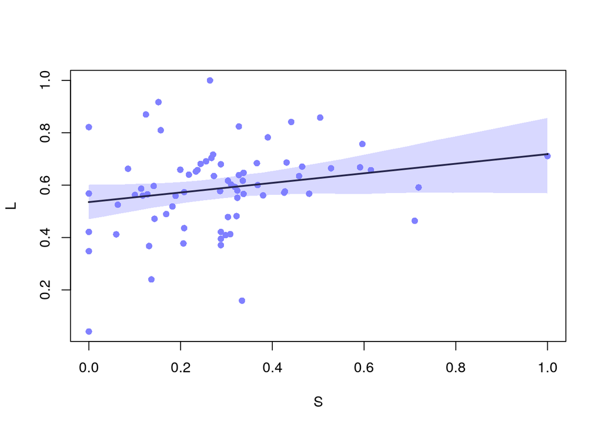

```r
plot(d$S, d$L, pch=16 , col=rangi2, xlab="S" , ylab="L" )
mu <- link( m8H4b , data=data.frame(S=S_seq ) )
mu_mean <- apply( mu , 2 , mean )
mu_ci <- apply( mu , 2 , PI , prob=0.97 )
lines( S_seq , mu_mean , lwd=2 )
shade( mu_ci , S_seq , col=col.alpha(rangi2,0.3) )
```

The evaluation does not support this claim.

3. ´mean.growing.season´ and ´sd.growing.season´ interact to synergistically reduce language diversity.

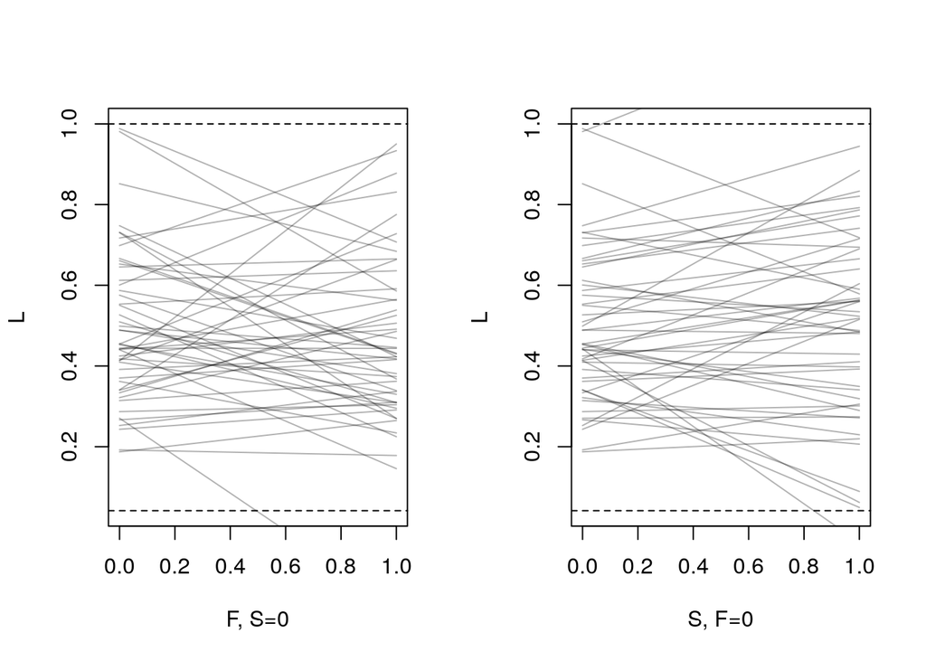

```r
set.seed(1)
m8H4c <- quap(
    alist(
        L ~ dnorm( mu , sigma ) ,
        mu <- a + bF*F + bFS*F*S + bS*S ,
        a ~ dnorm( 0.5 , 0.2 ) ,
        c(bF,bFS, bS) ~ dnorm( 0 , 0.2 ) ,
        sigma ~ dexp( 1 )
    ) , data=d )

prior <- extract.prior( m8H4c )

par(mfrow=c(1,2)) # 3 plots in 1 row
# 1. plot vary F
plot( NULL , xlim=c(0,1) , ylim=c(min(d$L),max(d$L)) ,
    xlab="F, S=0" , ylab="L" )
abline( h=min(d$L) , lty=2 )
abline( h=max(d$L) , lty=2 )

F_seq <- seq( from=min(d$F) , to=max(d$F) , length.out=30 )
mu <- link( m8H4c , post=prior , data=data.frame(S=0, F=F_seq) )
for ( i in 1:50 ) lines( F_seq , mu[i,] , col=col.alpha("black",0.3) )

# 1. plot vary S
plot( NULL , xlim=c(0,1) , ylim=c(min(d$L),max(d$L)) ,
    xlab="S, F=0" , ylab="L" )
abline( h=min(d$L) , lty=2 )
abline( h=max(d$L) , lty=2 )

S_seq <- seq( from=min(d$S) , to=max(d$S) , length.out=30 )
mu <- link( m8H4c , post=prior , data=data.frame(S=S_seq, F=0) )
for ( i in 1:50 ) lines( S_seq , mu[i,] , col=col.alpha("black",0.3) )
```

```r
set.seed(24071847)
PSIS_m8H4c <- PSIS(m8H4c,pointwise=TRUE)
```

```
## Some Pareto k values are high (>0.5). Set pointwise=TRUE to inspect individual points.
```

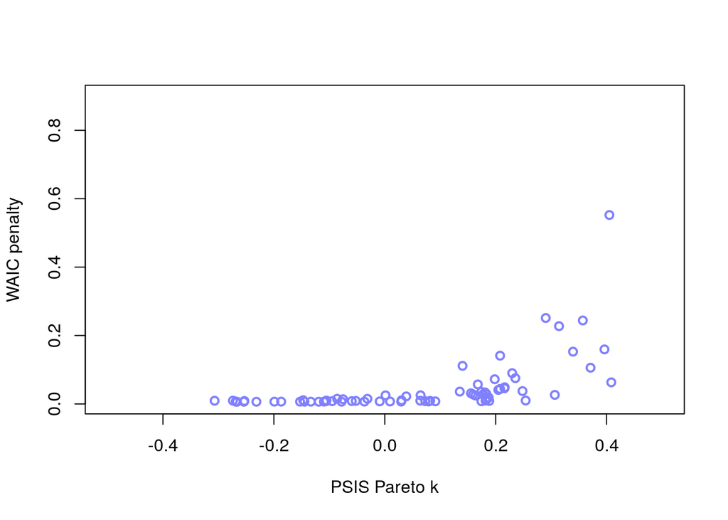

```r
set.seed(24071847)
WAIC_m8H4c <- WAIC(m8H4c,pointwise=TRUE)
plot( PSIS_m8H4c$k , WAIC_m8H4c$penalty , xlab="PSIS Pareto k" ,
    ylab="WAIC penalty" , col=rangi2 , lwd=2, xlim=c(-0.5,0.5) )
```

```r
precis(m8H4c)
```

```
##             mean         sd        5.5%      94.5%
## a      0.6593642 0.04658437  0.58491338  0.7338150
## bF    -0.2313908 0.06650032 -0.33767115 -0.1251104
## bFS    0.1912876 0.15713937 -0.05985144  0.4424267
## bS     0.1054495 0.11429999 -0.07722391  0.2881230
## sigma  0.1439077 0.01194107  0.12482353  0.1629918
```

- If there were no standard deviation in the growing season then: “The longer the growing season the less the language diversity.” Standard deviation on its own increases the language diversity and in combination with the average length of the growing season increases the language diversity.